# Weight Lifting Activity Recognition

gr3n4d3s

January 19, 2018

## Synopsis and objective

Human activity research(HAR) has had an influx of data thanks to devices like Fitbit, Jawbone Up and even some smart phones. Disseminating this data could be useful for a wide range of applications, from at home elderly care to extreme sports. Most often data is used to measure movement in a quantitative or discriminative sense to determine the amount or which exercise was performed. However, in this report we’ll take data from Groupware’s HAR research(1) on Bicep Curls to determine the quality of activity. The data collected was of six participants performing bicep curls in specific manners, both correctly(labeled A) and incorrectly(bad form, labeled B,C,D,E). This was collected via 4 accelerometers located on the bicep, waist, forearm and the dumbbell itself. Let’s not try to duplicate their report, but rather validate or reject it.  
(1)http://groupware.les.inf.puc-rio.br/work.jsf?p1=11201

## The Attack

### Preprocess

After a little exploring i notice that the data contain many NA’s associated with columns that had statistical data compiled from other columns of raw data. this was removed and the remaining set was tested for Near Zero-variance, documentation [here](https://topepo.github.io/caret/pre-processing.html).

##### Truncated sample

|  | freqRatio | percentUnique | zeroVar | nzv |
| --- | --- | --- | --- | --- |
| X | 1.00 | 100.00 | FALSE | FALSE |
| user_name | 1.10 | 0.03 | FALSE | FALSE |
| raw_timestamp_part_1 | 1.00 | 4.27 | FALSE | FALSE |
| raw_timestamp_part_2 | 1.00 | 85.53 | FALSE | FALSE |
| cvtd_timestamp | 1.00 | 0.10 | FALSE | FALSE |
| new_window | 47.33 | 0.01 | FALSE | TRUE |
| num_window | 1.00 | 4.37 | FALSE | FALSE |
| roll_belt | 1.10 | 6.78 | FALSE | FALSE |
| pitch_belt | 1.04 | 9.38 | FALSE | FALSE |
| yaw_belt | 1.06 | 9.97 | FALSE | FALSE |

Next step was to take a look a principal components to get an idea of what the data might look like and maybe understand which components had the most variance. This would then be useful for model selection and possibly number of components needed to explain a desired percent of variance.

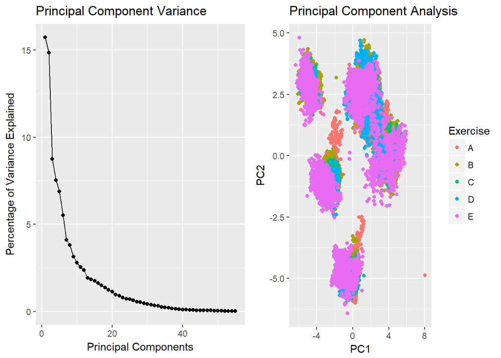

### Model building

As you can see from our previous analysis, 20 or so components make up the majority of our data variance(left plot). Also the structure of the data on the right would lead me to think that more of a classification training approach would be appropriate. lets train 3 different models and compare.  
Now although i do have a test set of data I’m going to spit my training data set into a training and test set as well. This will allow me to test my results against results that i know are correct so i can get and idea of how accurate the models will be. Lets see accuracies of Random Forests, Gradient Boosting and Linear Discriminate Analysis.

```
##          Random Forests Gradient Boosting Linear Discriminant
## Accuracy      0.9787928         0.8283034           0.5271207
```

Confusion Matrix Tables - left to right are: RF, GBM, LDA

|  | A | B | C | D | E |
| --- | --- | --- | --- | --- | --- |
| A | 1384 | 9 | 9 | 1 | 2 |
| B | 3 | 929 | 9 | 5 | 8 |
| C | 2 | 10 | 832 | 26 | 3 |
| D | 5 | 1 | 5 | 772 | 5 |
| E | 1 | 0 | 0 | 0 | 883 |

[output not shown]

[output not shown]

|  | A | B | C | D | E |
| --- | --- | --- | --- | --- | --- |
| A | 1238 | 96 | 32 | 31 | 17 |
| B | 40 | 720 | 55 | 34 | 65 |
| C | 42 | 89 | 737 | 90 | 48 |
| D | 66 | 29 | 18 | 630 | 34 |
| E | 9 | 15 | 13 | 19 | 737 |

[output not shown]

[output not shown]

|  | A | B | C | D | E |
| --- | --- | --- | --- | --- | --- |
| A | 913 | 182 | 221 | 63 | 120 |
| B | 116 | 422 | 86 | 126 | 142 |
| C | 113 | 165 | 451 | 125 | 117 |
| D | 191 | 105 | 66 | 384 | 107 |
| E | 62 | 75 | 31 | 106 | 415 |

### Final predictions

Random Forests shows the best promise for a good prediction model. Lets see the full statistics.

```
## Confusion Matrix and Statistics
##
##           Reference
## Prediction    A    B    C    D    E
##          A 1384    9    9    1    2
##          B    3  929    9    5    8
##          C    2   10  832   26    3
##          D    5    1    5  772    5
##          E    1    0    0    0  883
##
## Overall Statistics
##
##                Accuracy : 0.9788
##                  95% CI : (0.9744, 0.9826)
##     No Information Rate : 0.2845
##     P-Value [Acc > NIR] : < 2.2e-16
##
##                   Kappa : 0.9732
##  Mcnemar's Test P-Value : 4.218e-06
##
## Statistics by Class:
##
##                      Class: A Class: B Class: C Class: D Class: E
## Sensitivity            0.9921   0.9789   0.9731   0.9602   0.9800
## Specificity            0.9940   0.9937   0.9899   0.9961   0.9998
## Pos Pred Value         0.9851   0.9738   0.9530   0.9797   0.9989
## Neg Pred Value         0.9969   0.9949   0.9943   0.9922   0.9955
## Prevalence             0.2845   0.1935   0.1743   0.1639   0.1837
## Detection Rate         0.2822   0.1894   0.1697   0.1574   0.1801
## Detection Prevalence   0.2865   0.1945   0.1780   0.1607   0.1803
## Balanced Accuracy      0.9931   0.9863   0.9815   0.9781   0.9899
```

### Conclusion and answers

Now creating a training model based on the entire training data set (not just a subset), and use that model to predict our test questions. Why use the entire set now? Well, mainly because we can and probably should, but also there was a slight difference in predictions cast from a model built on 75% and 100% of the training data.

```
## [1] "Prediction using subset of training data"
```

```
##  [1] B A A A A E D B A A B C B A E E A B B B
## Levels: A B C D E
```

```
## [1] "prediction using all available training data"
```

```
##  [1] B A B A A E D B A A B C B A E E A B B B
## Levels: A B C D E
```

### Final thoughts

Random Forests was a great option to predict these kinds of problems. I never realized how much model selection plays into creating a good ML algo. I hope this was easier to understand than it was to create.  
And as always thanks for looking

#### code

```r
knitr::opts_chunk$set(echo = TRUE)
```

```r
library(dplyr)
library(caret)
library(ggplot2)
library(gridExtra)
library(xtable)
trainFileUrl <- "https://d396qusza40orc.cloudfront.net/predmachlearn/pml-training.csv"
testFileUrl <- "https://d396qusza40orc.cloudfront.net/predmachlearn/pml-testing.csv"

# download files
if (!file.exists("./pml-training.csv")) {
        mydir<- paste0(getwd(),"/","pml-training.csv")
        download.file(trainFileUrl, destfile = mydir)
}
if (!file.exists("./pml-testing.csv")){
        mydir<- paste0(getwd(),"/","pml-testing.csv")
        download.file(testFileUrl, destfile = mydir)
}

#read files into R *****edit stringsAsFactors = false
training <- read.csv("pml-training.csv", stringsAsFactors = FALSE)
testing <- read.csv("pml-testing.csv", stringsAsFactors = FALSE)

# reproducibility
set.seed(25)
```

```r
# no classe data in the testing data set which looking
# back now makes sense, soooooo split it to win it
inTrain <- createDataPartition(clntrain$classe, p = .75)[[1]]
xTraining <- clntrain[inTrain,]
xTesting <- clntrain[-inTrain,]

#turn on the afterburners... permission to buzz the tower
library(parallel)
library(doParallel)
library(knitr)
clustr <- makeCluster(detectCores()-1)
registerDoParallel(clustr)
#fit control allow for parallel processing
fitControl <- trainControl(method = "cv",
                           allowParallel = TRUE,
                           preProcOptions = list(thresh = .95))
#fit three models random forest, gradient boosting,
#and linear discriminant analysis
fitRf<- train(classe ~.,
                        data = xTraining,
                        method = "parRF",
                        preProcess = "pca",
                        trControl = fitControl)
#gabage wrapped to keep gbm output clean
garbage <- capture.output(
        fitGbm <- train(classe ~., data = xTraining,
                method = "gbm",
                preProcess = "pca",
                trControl = fitControl))

fitLda <- train(classe ~., data = xTraining,
                method = "lda",
                preProcess = "pca",
                trControl = fitControl)

predRf<- predict(fitRf, xTesting)
predGbm<- predict(fitGbm, xTesting)
predLda<- predict(fitLda, xTesting)


confMatRf <- confusionMatrix(predRf, xTesting$classe)
confMatGbm <- confusionMatrix(predGbm, xTesting$classe)
confMatLda <- confusionMatrix(predLda, xTesting$classe)

#show results
Accuracy <- data.frame(confMatRf$overall[1],confMatGbm$overall[1],
                       confMatLda$overall[1])
names(Accuracy)<- c("Random Forests", "Gradient Boosting",
                    "Linear Discriminant")

Accuracy
References <- kable(list(confMatRf$table,
                         "|","|",confMatGbm$table,
                         "|","|",confMatLda$table),
                    caption = c("Confusion Matrix Tables - left to right are:
                                RF, GBM, LDA"),
                    align = c("c"))
References
```

```r
confMatRf
```

```r
lastfitRf<- train(classe ~.,
                        data = clntrain,
                        method = "parRF",
                        preProcess = "pca",
                        trControl = fitControl)
stopCluster(clustr)
lastPred<- predict(lastfitRf, testing)
print("Prediction using subset of training data")
predict(fitRf, testing)
print("prediction using all available training data")
lastPred
```